| title: “Cryptography course analysis” |
| --- |
| author: “Kipsang Mutai Nicholas” |
| date: “01/22/2022” |

[output not shown]

## Online Cryptography analysis

### 1.Defining the Question.

This research is meant to identify the specific individuals who are likely to click on an advertisement add.

#### a.) Who is likely to click the online cryptography course advertisement?

## 2.) Metrics of success

My success will be achieved by correctly identifying individuals that are likely to click into an add. This will be achieved by performing and in depth review of the data at hand to analyse factors influencing the advertisement clicks while assessing individual independent variables and their distribution within the set and their relationship with one another.

## 3.) The context of analysis.

The online cryptography course is a new field involved with ensuring secure communication between two individuals. This field though new, could improve information security. Using data collected from a former advertisement on a related course posted on a blog, we can get to view the recipient behavior of this advertisements so as to maximize on high priority recipients to ensure effective advertising and return on investment made in the business by not concentrating on low target potential customers.

## 4.) Experimental design taken

This will involve exhaustive techniques to understand our data in and out. This will be done by finding and dealing with extreem values ,anomalies, missing values and duplicated values to ensure the data used is an actual representative of the actual observations. This will be followed by and exhaustive analysis of the attributes (variables) of the data.Using the inference borrowed from our analysis , we will obtain answers to our specific question while challenging the solution by providing how to make improvements to ensure optimum marketing is achieved.

## 5.) Dataset appropriateness for analysis

A brief review of the data to inform us what we are working with and its importance for analysis.

```r
# Loading our dataset.
library(data.table)
advert_df<-fread("http://bit.ly/IPAdvertisingData")
# Checking the first 6 observations
head(advert_df)
```

```
##    Daily Time Spent on Site Age Area Income Daily Internet Usage
## 1:                    68.95  35    61833.90               256.09
## 2:                    80.23  31    68441.85               193.77
## 3:                    69.47  26    59785.94               236.50
## 4:                    74.15  29    54806.18               245.89
## 5:                    68.37  35    73889.99               225.58
## 6:                    59.99  23    59761.56               226.74
##                            Ad Topic Line           City Male    Country
## 1:    Cloned 5thgeneration orchestration    Wrightburgh    0    Tunisia
## 2:    Monitored national standardization      West Jodi    1      Nauru
## 3:      Organic bottom-line service-desk       Davidton    0 San Marino
## 4: Triple-buffered reciprocal time-frame West Terrifurt    1      Italy
## 5:         Robust logistical utilization   South Manuel    0    Iceland
## 6:       Sharable client-driven software      Jamieberg    1     Norway
##              Timestamp Clicked on Ad
## 1: 2016-03-27 00:53:11             0
## 2: 2016-04-04 01:39:02             0
## 3: 2016-03-13 20:35:42             0
## 4: 2016-01-10 02:31:19             0
## 5: 2016-06-03 03:36:18             0
## 6: 2016-05-19 14:30:17             0
```

### Checking the structure of my dataset.

```r
# Reviewing the dimensions making my table
dimensions <-dim(advert_df)
dimensions
```

```
## [1] 1000   10
```

My dataset has a thousand observations and 10 variables of numerical,integer character datatypes. There is also time stamp variable within the data.

## 6.) Cleaning the dataset.

This will be aimed at identifying extreme values, anomalies within the set,missing values and duplicated values in the set.

```r
colnames(advert_df)
```

```
##  [1] "Daily Time Spent on Site" "Age"
##  [3] "Area Income"              "Daily Internet Usage"
##  [5] "Ad Topic Line"            "City"
##  [7] "Male"                     "Country"
##  [9] "Timestamp"                "Clicked on Ad"
```

```r
# Changing the column names for easy readability
colnames(advert_df)<-c("Time_on_site","Age","A_income","Internet_Usage","Ad_Topic","City","Male","Country","Timestamp","Clicked")
```

### a.) Numeric datatypes

```r
# Identifying outliers in the numerical columns
library("dplyr")
nums_df<-select_if(advert_df,is.numeric)
nums_df
```

```
##       Time_on_site Age A_income Internet_Usage Male Clicked
##    1:        68.95  35 61833.90         256.09    0       0
##    2:        80.23  31 68441.85         193.77    1       0
##    3:        69.47  26 59785.94         236.50    0       0
##    4:        74.15  29 54806.18         245.89    1       0
##    5:        68.37  35 73889.99         225.58    0       0
##   ---
##  996:        72.97  30 71384.57         208.58    1       1
##  997:        51.30  45 67782.17         134.42    1       1
##  998:        51.63  51 42415.72         120.37    1       1
##  999:        55.55  19 41920.79         187.95    0       0
## 1000:        45.01  26 29875.80         178.35    0       1
```

### Rechecking the column names

```r
colnames(advert_df)
```

```
##  [1] "Time_on_site"   "Age"            "A_income"       "Internet_Usage"
##  [5] "Ad_Topic"       "City"           "Male"           "Country"
##  [9] "Timestamp"      "Clicked"
```

### A function to check for outliers within the numerical values of the set

```r
# Boxplot of the individual variables
box_plot<-function(data,var,main){
  boxplot(data[[var]],ylab="Distribution of values",main=main)
}
```

### A boxplot of the daily time spent onsite to check for outliers

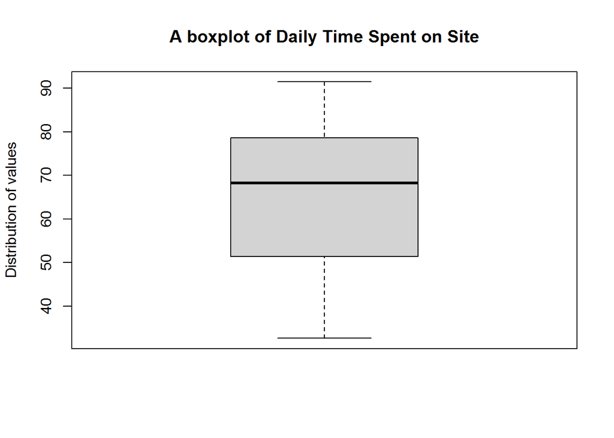

```r
box_plot(nums_df,1,"A boxplot of Daily Time Spent on Site")
```

```r
# There are no outliers in the values in the daily time spent on the site
```

### A boxplot of Age to check for outliers

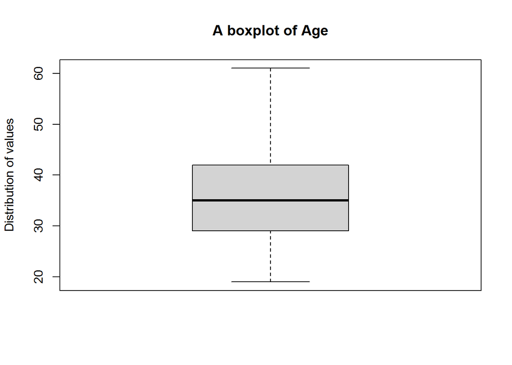

```r
box_plot(nums_df,2,"A boxplot of Age")
```

```r
# There are no outliers in the Age distribution
```

### A boxplot of income to check for outliers

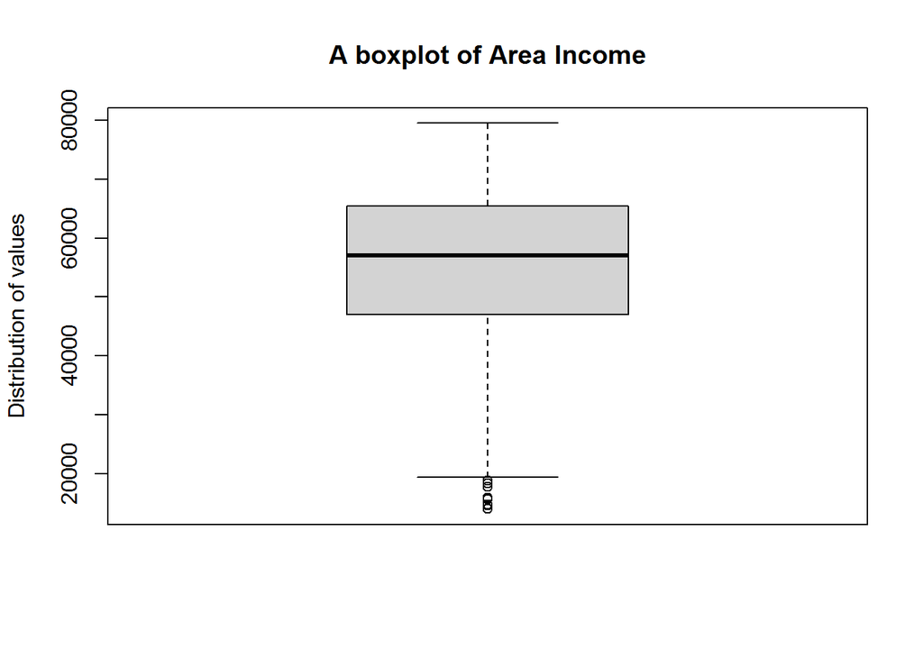

```r
box_plot(nums_df,3,"A boxplot of Area Income")
```

```r
# There are several outliers lying below the 25th percentile
```

### A box plot of Daily Internet Usage to check for outliers

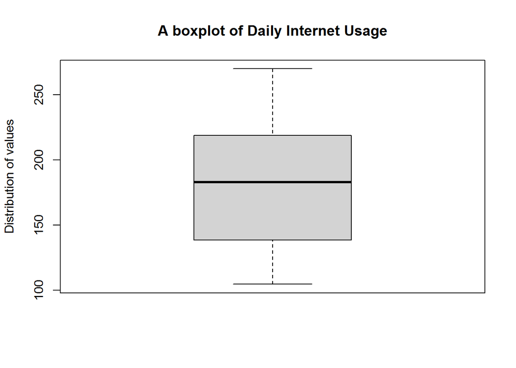

```r
box_plot(nums_df,4,"A boxplot of Daily Internet Usage")
```

```r
# There are no outliers in the daily internet usage values
```

### A boxplot to check for outliers on whether an individual is male or not

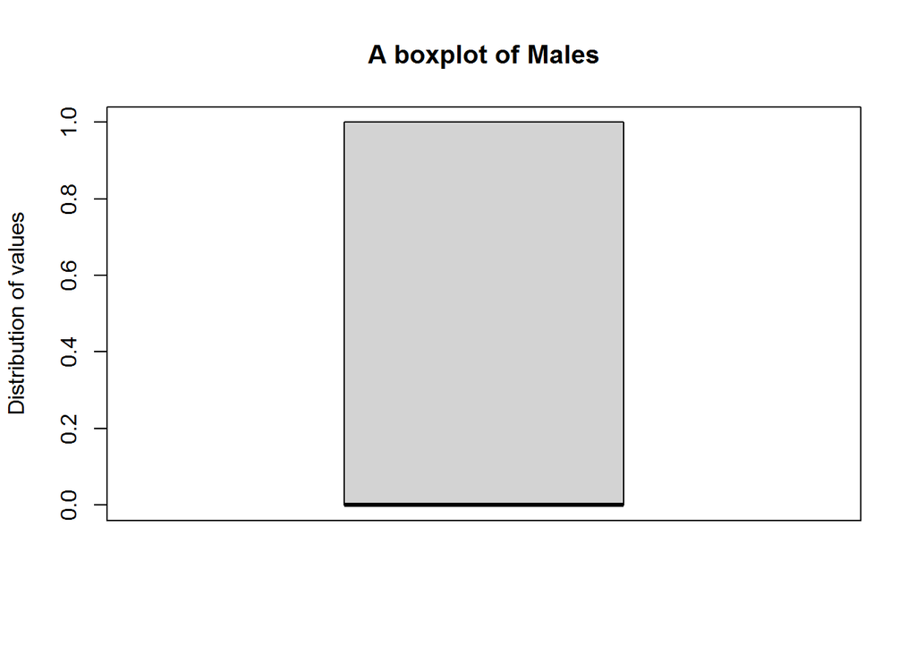

```r
box_plot(nums_df,5,"A boxplot of Males")
```

```r
# There are no  anomalies nor outliers in the male column. Since values are either 0's or 1's for Yes and No respectively
```

### A boxplot of Clicked on Ad to check for outliers

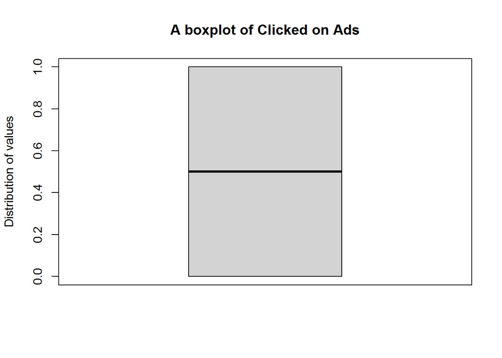

```r
box_plot(nums_df,6,"A boxplot of Clicked on Ads")
```

```r
# No anomaly nor outliers detected in this set
```

### Anomalies and Outliers in the Non-numeric columns.

```r
Numerics<-noquote(names(nums_df))
Numerics
```

```
## [1] Time_on_site   Age            A_income       Internet_Usage Male
## [6] Clicked
```

```r
non_nums<-subset(advert_df,select = -c(Time_on_site,Age,A_income,Internet_Usage,Male,Clicked))
```

```r
head(non_nums)
```

```
##                                 Ad_Topic           City    Country
## 1:    Cloned 5thgeneration orchestration    Wrightburgh    Tunisia
## 2:    Monitored national standardization      West Jodi      Nauru
## 3:      Organic bottom-line service-desk       Davidton San Marino
## 4: Triple-buffered reciprocal time-frame West Terrifurt      Italy
## 5:         Robust logistical utilization   South Manuel    Iceland
## 6:       Sharable client-driven software      Jamieberg     Norway
##              Timestamp
## 1: 2016-03-27 00:53:11
## 2: 2016-04-04 01:39:02
## 3: 2016-03-13 20:35:42
## 4: 2016-01-10 02:31:19
## 5: 2016-06-03 03:36:18
## 6: 2016-05-19 14:30:17
```

### Checking for unique values in each column

```r
print(length(unique(non_nums[[1]])))
```

```
## [1] 1000
```

```r
print(length(unique(non_nums[[2]])))
```

```
## [1] 969
```

```r
print(length(unique(non_nums[[3]])))
```

```
## [1] 237
```

### Dealing with Outliers in the Area of income set

# Checking the numbers outside the InterQuantile range

```r
boxplot.stats(advert_df$A_income)$out
```

```
## [1] 17709.98 18819.34 15598.29 15879.10 14548.06 13996.50 14775.50 18368.57
```

# Checking for legitimacy of the outliers by checking the maximum and the minimum

```r
print(max(advert_df$A_income))
```

```
## [1] 79484.8
```

```r
print(min(advert_df$A_income))
```

```
## [1] 13996.5
```

# They wont be regarded as illegitimate data points as they are not too extreem

### Checking for Duplicates

```r
# Checking for duplicated rows
length(advert_df[duplicated(advert_df),])
```

```
## [1] 10
```

```r
clean_df<-advert_df[!duplicated(advert_df),]

clean_df
```

```
##       Time_on_site Age A_income Internet_Usage
##    1:        68.95  35 61833.90         256.09
##    2:        80.23  31 68441.85         193.77
##    3:        69.47  26 59785.94         236.50
##    4:        74.15  29 54806.18         245.89
##    5:        68.37  35 73889.99         225.58
##   ---
##  996:        72.97  30 71384.57         208.58
##  997:        51.30  45 67782.17         134.42
##  998:        51.63  51 42415.72         120.37
##  999:        55.55  19 41920.79         187.95
## 1000:        45.01  26 29875.80         178.35
##                                    Ad_Topic           City Male
##    1:    Cloned 5thgeneration orchestration    Wrightburgh    0
##    2:    Monitored national standardization      West Jodi    1
```

[output cut: 21 more lines]

### confirming the operation

```r
clean_df[duplicated(clean_df),]
```

```
## Empty data.table (0 rows and 10 cols): Time_on_site,Age,A_income,Internet_Usage,Ad_Topic,City...
```

### Checking for null values

```r
# Length which is null
length(which(is.na.data.frame(clean_df)))
```

```
## [1] 0
```

# There are no missing values in the set

### Reextracting numerical variables from clean data

```r
# Re-extracting numerical values from the clean data with no duplicates
library("dplyr")
clean_nums_df<-select_if(clean_df,is.numeric)
clean_nums_df
```

```
##       Time_on_site Age A_income Internet_Usage Male Clicked
##    1:        68.95  35 61833.90         256.09    0       0
##    2:        80.23  31 68441.85         193.77    1       0
##    3:        69.47  26 59785.94         236.50    0       0
##    4:        74.15  29 54806.18         245.89    1       0
##    5:        68.37  35 73889.99         225.58    0       0
##   ---
##  996:        72.97  30 71384.57         208.58    1       1
##  997:        51.30  45 67782.17         134.42    1       1
##  998:        51.63  51 42415.72         120.37    1       1
##  999:        55.55  19 41920.79         187.95    0       0
## 1000:        45.01  26 29875.80         178.35    0       1
```

## 7. Univariate Analysis

### Measures of Central Tendacy

```r
# Numerical values
head(clean_nums_df)
```

```
##    Time_on_site Age A_income Internet_Usage Male Clicked
## 1:        68.95  35 61833.90         256.09    0       0
## 2:        80.23  31 68441.85         193.77    1       0
## 3:        69.47  26 59785.94         236.50    0       0
## 4:        74.15  29 54806.18         245.89    1       0
## 5:        68.37  35 73889.99         225.58    0       0
## 6:        59.99  23 59761.56         226.74    1       0
```

# Mean of individual columns

```r
# Mean of individual columns
colMeans(clean_nums_df)
```

```
##   Time_on_site            Age       A_income Internet_Usage           Male
##        65.0002        36.0090     55000.0001       180.0001         0.4810
##        Clicked
##         0.5000
```

The values as valid especially for the 0’s and 1’s columns the mean is approximately 0.5 giving us a clue of the distribution of the discrete values.

```r
#A summary of everything in numerical set
summary.data.frame(clean_nums_df)
```

```
##   Time_on_site        Age           A_income     Internet_Usage
##  Min.   :32.60   Min.   :19.00   Min.   :13996   Min.   :104.8
##  1st Qu.:51.36   1st Qu.:29.00   1st Qu.:47032   1st Qu.:138.8
##  Median :68.22   Median :35.00   Median :57012   Median :183.1
##  Mean   :65.00   Mean   :36.01   Mean   :55000   Mean   :180.0
##  3rd Qu.:78.55   3rd Qu.:42.00   3rd Qu.:65471   3rd Qu.:218.8
##  Max.   :91.43   Max.   :61.00   Max.   :79485   Max.   :270.0
##       Male          Clicked
##  Min.   :0.000   Min.   :0.0
##  1st Qu.:0.000   1st Qu.:0.0
##  Median :0.000   Median :0.5
##  Mean   :0.481   Mean   :0.5
##  3rd Qu.:1.000   3rd Qu.:1.0
##  Max.   :1.000   Max.   :1.0
```

### Histogram of the individual columns to see their distribution

For continous variables a histogram is paramount to display the distribution of values in the set while telling us the skewness and kurtosis of out data

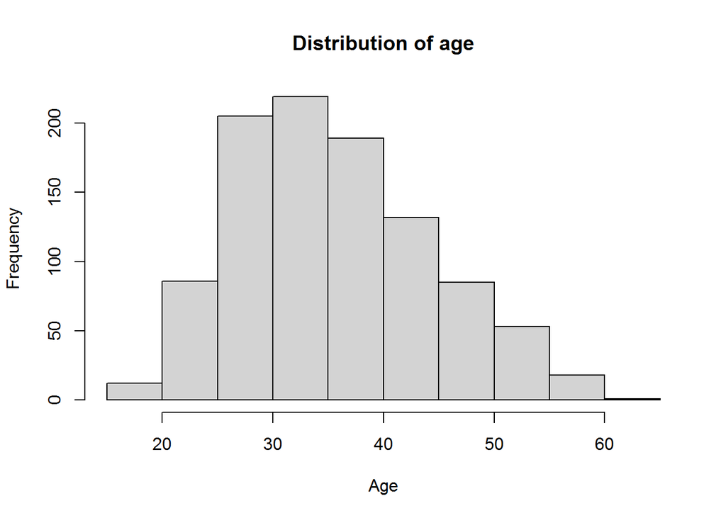

```r
hist(clean_nums_df$Age,xlab="Age",main="Distribution of age")
```

# Distribution of the time on sight

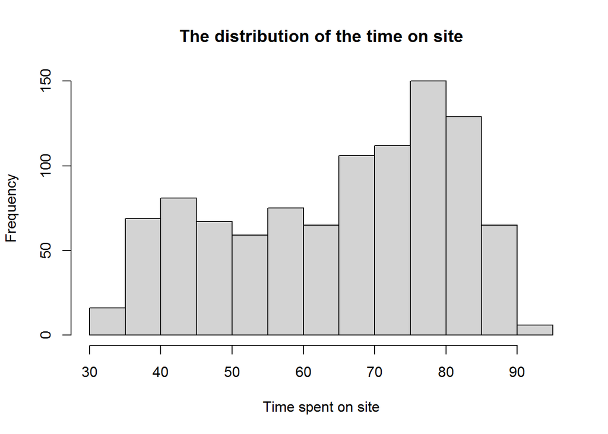

```r
hist(clean_nums_df$Time_on_site,xlab = "Time spent on site",main="The distribution of the time on site")
```

Frequency of Time spent is relatively high the 3rd quantile of the set. This tells us that a significantly large amount of time is spent on the site

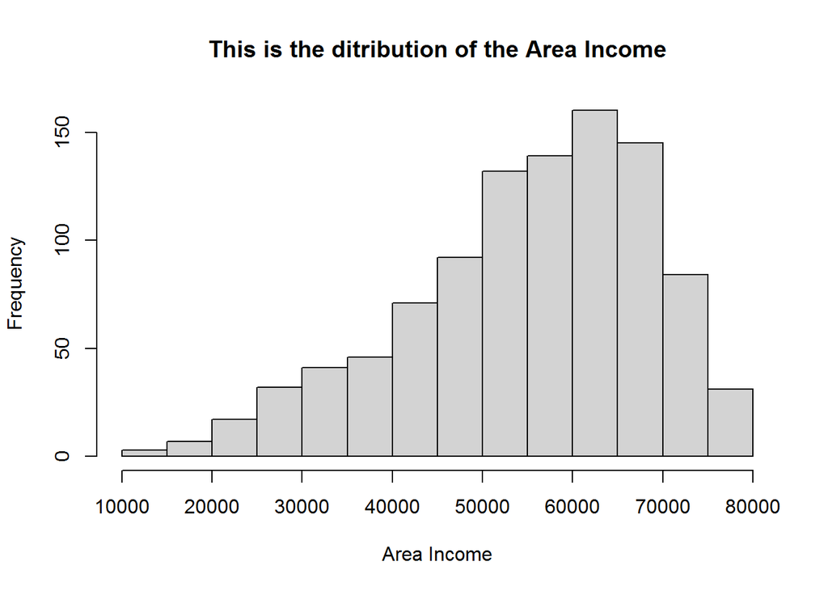

```r
# Distribution of area income
hist(clean_nums_df$A_income,xlab="Area Income",main="This is the ditribution of the Area Income")
```

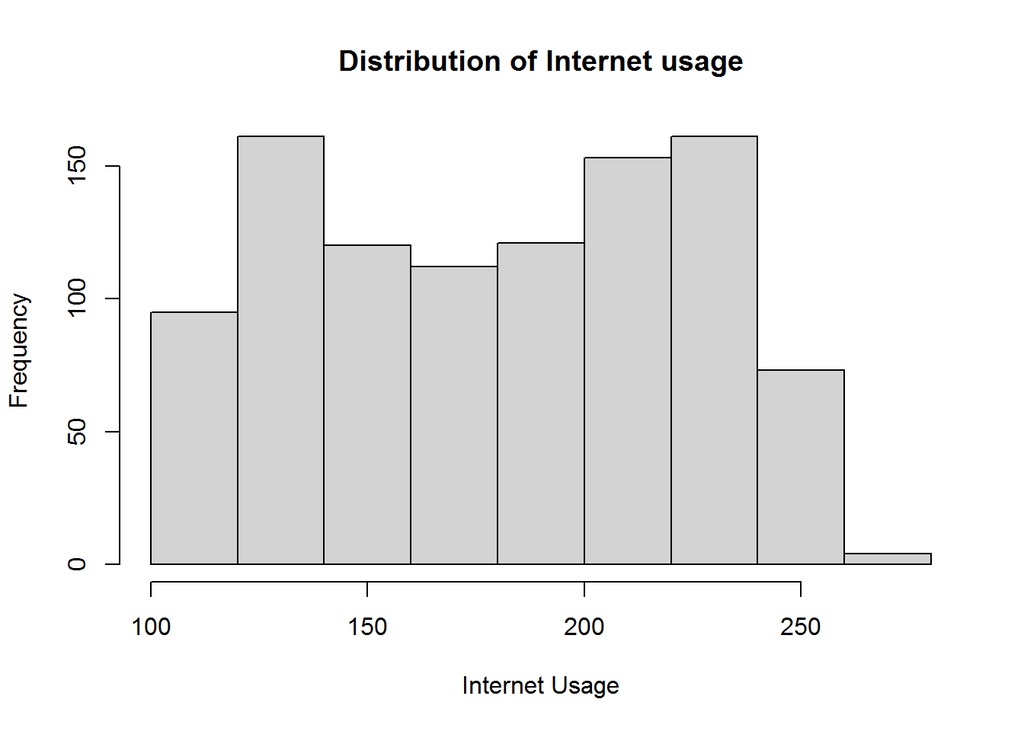

```r
# Internet usage
hist(clean_nums_df$Internet_Usage,xlab="Internet Usage",main="Distribution of Internet usage")
```

## Discrete Variables

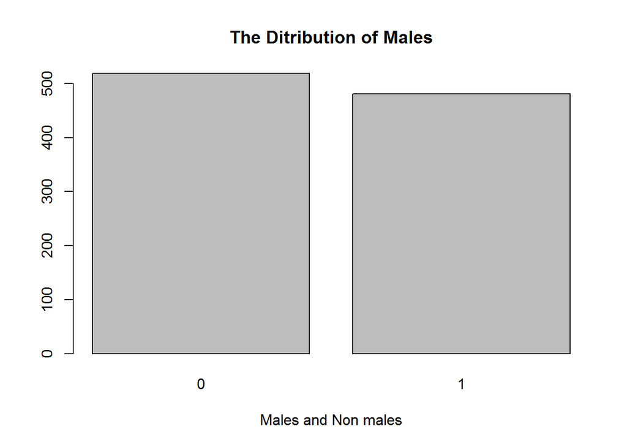

```r
# Getting the values in the male variable
males<-clean_nums_df$Male
# Getting the frequency table of the male set
male_dist<-table(males)
# Plotting a bar plot to understand the distribution of discrete values in the males column
barplot(male_dist,main = "The Ditribution of Males",xlab = "Males and Non males")
```

# The non male which i would presume to be female were higher in count as compared to males

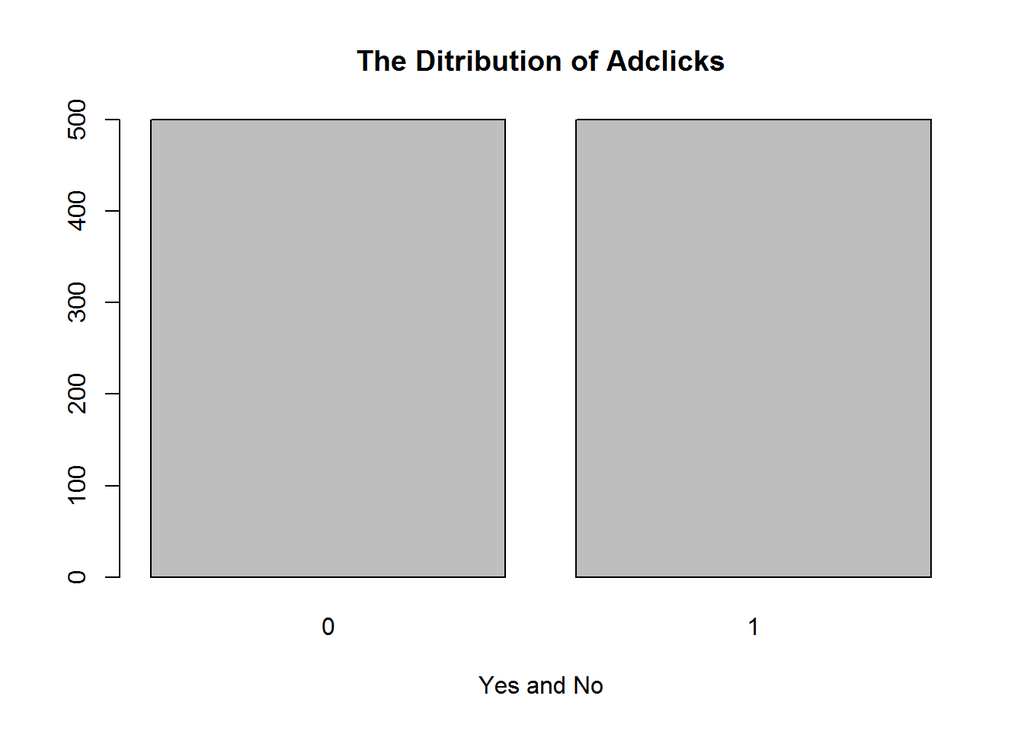

```r
# Getting the values in the clicks
ad_clicks<-clean_nums_df$Clicked
# Getting the frequency table of the clicks set
ad_clicks_dist<-table(ad_clicks)
# Plotting a bar plot to understand the distribution of discrete values in the clicks column
barplot(ad_clicks_dist,main = "The Ditribution of Adclicks",xlab = "Yes and No")
```

The distribution was balanced.